# Practical Machine Learning Course Project

Evgeny Gorelov

4/1/2019

## Preparing the data

In order to make the analysis reproducable, the script starts from files download, and the random number seed is set:

```r
library(caret)
```

```r
set.seed(123)
if (!file.exists("pml-training.csv"))
   download.file("https://d396qusza40orc.cloudfront.net/predmachlearn/pml-training.csv", "pml-training.csv")
if (!file.exists("pml-testing.csv"))
   download.file("https://d396qusza40orc.cloudfront.net/predmachlearn/pml-testing.csv", "pml-testing.csv")
trSet<-read.csv("pml-training.csv")
cases<-read.csv("pml-testing.csv")
```

The dataset contains number of factor variables of numeric nature, and some non-informative for our purpoces variables: **user_name**, **cvtd_timestamp**. The factor variables are converted to numeric format, extra variables removed:

```r
trSet<-trSet[,!(names(trSet)%in% c("user_name","cvtd_timestamp","new_window"))]
cases<-cases[,!(names(cases)%in% c("user_name","cvtd_timestamp","new_window"))]
classeBak<-trSet$classe
trSet<-data.frame(lapply(trSet, function(x) as.numeric(as.character(x))))
trSet$classe<-classeBak
cases<-data.frame(lapply(cases, function(x) as.numeric(as.character(x))))
```

Since the dataset contains many variables with *NA* values dominating, these predictors (having overall *NA* quote more than 97%) will be omitted, and the rest entries are free from NA values. In order to keep the model consistent, the same procedure is performed on the target **cases** data:

```r
trSetClean<-trSet[,sapply(trSet,function(col){sum(is.na(col))<0.97*length(col)})]
sum(complete.cases(trSetClean)); dim(trSetClean)
```

```
## [1] 19622
```

```
## [1] 19622    57
```

```r
casesClean<-cases[,sapply(trSet,function(col){sum(is.na(col))<0.97*length(col)})]
dim(casesClean)
```

```
## [1] 20 57
```

## Data analysis

### Data partitioning

Sinse the data set is quite big (19622 observations), we can perform the validation procedure. The testing set is splitted: 30% to validation set, and rest to training (70%) and testing (30%). In order to demonstrate cross-validation procedure, two additional splittings to training/testing sets are performed:

```r
inValidat<-createDataPartition(y=trSetClean$classe, p=0.3, list=FALSE)
validation<-trSetClean[inValidat,]; Build<-trSetClean[-inValidat,]
inTrain<-createDataPartition(y=Build$classe, p=0.7, list=FALSE)
training<-Build[inTrain,]; testing<-Build[-inTrain,]
inTrain<-createDataPartition(y=Build$classe, p=0.7, list=FALSE)
training2<-Build[inTrain,]; testing2<-Build[-inTrain,]
inTrain<-createDataPartition(y=Build$classe, p=0.7, list=FALSE)
training3<-Build[inTrain,]; testing3<-Build[-inTrain,]
```

### Principal component construction

Since number of predictors (56) is still high, and, according to origin of the data, some of them could be highly correlated, a Principle Component-based preprocessing is used. In order to capture 70 percent of the variance, it is enough to use 9 to 11 principal components, depending on selection of the training set:

```r
preProc<-preProcess(training[,-57], method="pca", thresh=0.7)
preProc$numComp
```

```
## [1] 11
```

```r
trainPC<-cbind(predict(preProc, training[,-57]), classe=training[,57]); testPC<-predict(preProc, testing[,-57])
preProc2<-preProcess(training2[,-57], method="pca", thresh=0.7)
preProc2$numComp
```

```
## [1] 9
```

```r
trainPC2<-cbind(predict(preProc2, training2[,-57]), classe=training[,57]); testPC2<-predict(preProc2, testing2[,-57])
preProc3<-preProcess(training3[,-57], method="pca", thresh=0.7)
preProc3$numComp
```

```
## [1] 11
```

```r
trainPC3<-cbind(predict(preProc3, training3[,-57]), classe=training[,57]); testPC3<-predict(preProc3, testing3[,-57])
validationPC<-predict(preProc, validation[,-57]);validationPC2<-predict(preProc2, validation[,-57]);validationPC3<-predict(preProc3, validation[,-57])
casesPC<-predict(preProc, casesClean[,-57]);casesPC2<-predict(preProc2, casesClean[,-57]);casesPC3<-predict(preProc3, casesClean[,-57])
```

### Models fit and error analysis

Among the variety of models tried for the task, the two demonstrated reasonable prediction accuracy (above 70%) and being able to run on 8GB RAM machine: **Random Forest** and **gradient boosted** models. In order to perform cross-validation and error estimation, each model is fitted three times, using *training*, *training2*, and *training3* sets for fitting, and *testing*, *testing2*, and *testing3* for estimating the out-of-sample error by cross-validation.

```r
mod1a<-train(classe~., method="rf", data=trainPC)
mod2a<-train(classe~., method="gbm", data=trainPC, verbose=FALSE)
mod1b<-train(classe~., method="rf", data=trainPC2)
mod2b<-train(classe~., method="gbm", data=trainPC2, verbose=FALSE)
mod1c<-train(classe~., method="rf", data=trainPC3)
mod2c<-train(classe~., method="gbm", data=trainPC3, verbose=FALSE)
errA<-confusionMatrix(testing$classe, predict(mod1a, testPC))$overall[1]
errB<-confusionMatrix(testing2$classe, predict(mod1b, testPC2))$overall[1]
errC<-confusionMatrix(testing3$classe, predict(mod1c, testPC3))$overall[1]
1.0-mean(c(errA, errB, errC))
```

```
## [1] 0.05002428
```

```r
errA<-confusionMatrix(testing$classe, predict(mod2a, testPC))$overall[1]
errB<-confusionMatrix(testing2$classe, predict(mod2b, testPC2))$overall[1]
errC<-confusionMatrix(testing3$classe, predict(mod2c, testPC3))$overall[1]
1.0-mean(c(errA, errB, errC))
```

```
## [1] 0.2230047
```

The error estimated by cross-validation is 5% for **rf** method, and 22% for **gbm**. However, desining data partitioning the **validation** independent set have been generated, so true out-of-sample error rate is

```r
errA<-confusionMatrix(validation$classe, predict(mod1a, validationPC))$overall[1]
errB<-confusionMatrix(validation$classe, predict(mod1b, validationPC2))$overall[1]
errC<-confusionMatrix(validation$classe, predict(mod1c, validationPC3))$overall[1]
1.0-mean(c(errA, errB, errC))
```

```
## [1] 0.04901794
```

```r
errA<-confusionMatrix(validation$classe, predict(mod2a, validationPC))$overall[1]
errB<-confusionMatrix(validation$classe, predict(mod2b, validationPC2))$overall[1]
errC<-confusionMatrix(validation$classe, predict(mod2c, validationPC3))$overall[1]
1.0-mean(c(errA, errB, errC))
```

```
## [1] 0.2309956
```

The out-of-sample error is 5% for **rf** method, and 23% for **gbm**, it is very close to cross-validation estimations. The confidence intervals for accuracy associated with in-sample error for two type of models (**rf** and **gbm**) and three train/test partitionings for each model are shown below:

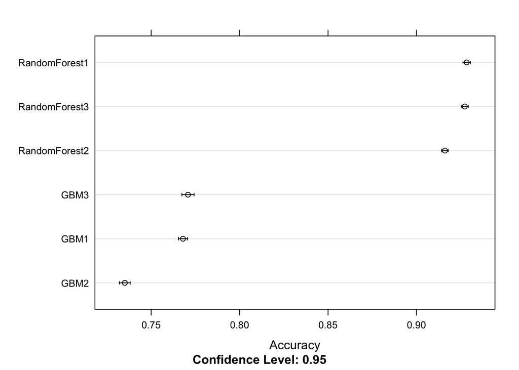

```r
resmp<-resamples(list(RandomForest1=mod1a, RandomForest2=mod1b, RandomForest3=mod1c,
                      GBM1=mod2a, GBM2=mod2b, GBM3=mod2c))
trellis.par.set(caretTheme())
dotplot(resmp, metric = "Accuracy")
```

### Model stacking

In order to maintain high prediction accuracy, the model stacking method is implemented:

```r
predDF<-data.frame(pred1=predict(mod1a, testPC),pred2=predict(mod1b, testPC2),pred3=predict(mod1c, testPC3),pred4=predict(mod2a, testPC),pred5=predict(mod2b, testPC2),pred6=predict(mod2c, testPC3),classe=testing$classe)

combModFit<-train(classe~., method="rf", data=predDF)

predVDF<-data.frame(pred1=predict(mod1a, validationPC),pred2=predict(mod1b, validationPC2),pred3=predict(mod1c, validationPC3),pred4=predict(mod2a, validationPC),pred5=predict(mod2b, validationPC2),pred6=predict(mod2c, validationPC3))

combPredV<-predict(combModFit, predVDF)
1.0-confusionMatrix(validation$classe, combPredV)$overall[1]
```

```
##  Accuracy
## 0.0397351
```

The out-of-sample error rate for stacked model is 4%, that is better than any individual model used in the stacking.

Applying the resulting stacked model to the target Quiz **cases** data set, we obtain

```r
cases6<-data.frame(pred1=predict(mod1a, casesPC),pred2=predict(mod1b, casesPC2),pred3=predict(mod1c, casesPC3),pred4=predict(mod2a, casesPC),pred5=predict(mod2b, casesPC2),pred6=predict(mod2c, casesPC3))
data.frame(predict(combModFit, cases6))
```

```
##    predict.combModFit..cases6.
## 1                            B
## 2                            A
## 3                            A
## 4                            A
## 5                            A
## 6                            E
## 7                            D
## 8                            B
## 9                            A
## 10                           A
## 11                           A
## 12                           C
## 13                           B
## 14                           A
## 15                           E
## 16                           E
## 17                           A
## 18                           B
## 19                           B
## 20                           B
```